# Scanpy scRNA-seq pipeline on Smillie 2019 UC data

## 13. Myeloid zoom-in

Subset to cells annotated as `Myeloid`, then re-run HVG â†’ PCA â†’ neighbours â†’ UMAP â†’ Leiden on that compartment alone. This teases apart subpopulations (monocytes, macrophages, cDC1, cDC2, pDC) that look like one blob at the whole-dataset level.

Common myeloid subtype markers:

| Subtype | Markers |
| --- | --- |
| Classical monocyte | `CD14`, `S100A8`, `S100A9`, `VCAN` |
| Non-classical monocyte | `FCGR3A` (CD16), `MS4A7`, `CDKN1C` |
| Macrophage (gut-resident) | `C1QA`, `C1QB`, `C1QC`, `APOE` |
| cDC1 | `CLEC9A`, `XCR1`, `IRF8`, `BATF3` |
| cDC2 | `CLEC10A`, `CD1C`, `FCER1A` |
| pDC | `LILRA4`, `GZMB`, `IRF7` |

**Skip this section in PBMC3k fallback** â€” only 2700 cells, myeloid subset will be tiny and noisy.

```python
if "Myeloid" in adata.obs["cell_type"].cat.categories:
    # Start from the full log-normalised matrix in .raw, subset to myeloid cells.
    mye = adata.raw.to_adata()[adata.obs["cell_type"] == "Myeloid"].copy()
    sc.pp.highly_variable_genes(mye, n_top_genes=2000, flavor="seurat")
    mye = mye[:, mye.var["highly_variable"]].copy()
    sc.pp.scale(mye, max_value=10)
    sc.tl.pca(mye, svd_solver="arpack")
    sc.pp.neighbors(mye, n_neighbors=10, n_pcs=20)
    sc.tl.umap(mye)
    sc.tl.leiden(mye, resolution=0.5, key_added="leiden_mye")
    sc.pl.umap(mye, color="leiden_mye", legend_loc="on data")

    mye_markers = {
        "Classical mono": ["CD14", "S100A8", "S100A9", "VCAN"],
        "Non-classical mono": ["FCGR3A", "MS4A7", "CDKN1C"],
        "Macrophage": ["C1QA", "C1QB", "C1QC", "APOE"],
        "cDC1": ["CLEC9A", "XCR1", "IRF8", "BATF3"],
        "cDC2": ["CLEC10A", "CD1C", "FCER1A"],
        "pDC": ["LILRA4", "GZMB", "IRF7"],
    }
    # Restrict to markers actually present in the myeloid subset's gene list.
    mye_markers = {k: [g for g in v if g in mye.var_names] for k, v in mye_markers.items()}
    mye_markers = {k: v for k, v in mye_markers.items() if v}
    sc.pl.dotplot(mye, mye_markers, groupby="leiden_mye", standard_scale="var")
else:
    print("No Myeloid cluster — skip this section (expected in PBMC3k fallback run).")
```

```
No Myeloid cluster — skip this section (expected in PBMC3k fallback run).
```

```
WARNING: saving figure to file figures\umap_celltype.png
```

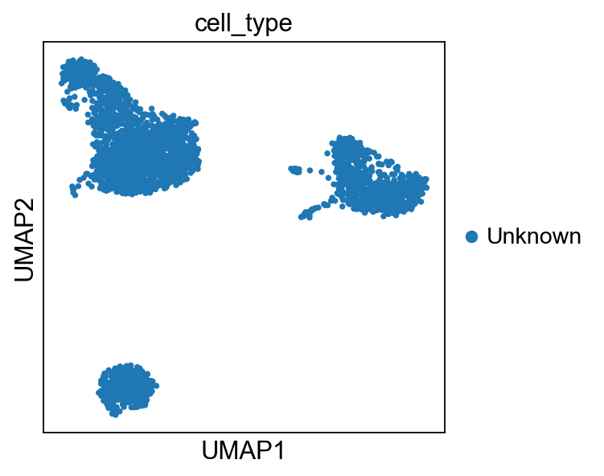

```python
sc.pl.umap(
    adata,
    color="cell_type",
    groups=None,
    save="_celltype.png",
)

if adata.obs["condition"].nunique() > 1:
    sc.pl.umap(
        adata,
        color="cell_type",
        ncols=2,
        save="_celltype_by_condition.png",
    )
    # facet manually by condition â€” Scanpy's native `groupby` faceting is limited.
    import matplotlib.pyplot as plt
    conditions = adata.obs["condition"].cat.categories if hasattr(adata.obs["condition"], "cat") else adata.obs["condition"].unique()
    fig, axes = plt.subplots(1, len(conditions), figsize=(6 * len(conditions), 5))
    if len(conditions) == 1:
        axes = [axes]
    for ax, cond in zip(axes, conditions):
        sc.pl.umap(adata[adata.obs["condition"] == cond], color="cell_type", ax=ax, show=False, title=cond)
    plt.tight_layout()
```

## 15. Save processed AnnData

Serialise the fully-annotated object to `data/processed/` for reuse. HDF5 format â€” portable, fast, readable from both Python (`sc.read_h5ad`) and R (via `zellkonverter`).

```python
import os
os.makedirs("../data/processed", exist_ok=True)
out = "../data/processed/smillie_annotated.h5ad" if not USE_PBMC_FALLBACK else "../data/processed/pbmc3k_annotated.h5ad"
adata.write_h5ad(out)
print(f"Wrote {out}")
```

```
Wrote ../data/processed/pbmc3k_annotated.h5ad
```